# After-Class Practice

KONG Lingtong (Alex)

2/25/2021

# R session: Loading market data

```r
library(xts)  # to manipulate time series of stock data
library(quantmod)  # to download stock data
library(PerformanceAnalytics)  # to compute performance measures
# download data from YahooFinance
stock_namelist <- c("AMD", "ADI", "APD", "BA", "0001.HK", "DD", "M", "JNPR", "INTC", "GS", "IBM", "NOK", "XOM", "WFC")
prices <- xts()
for (i in 1:length(stock_namelist)) {
  tmp <- Ad(getSymbols(stock_namelist[i], from = "2005-01-01", to = "2008-12-31", auto.assign = FALSE))
  #tmp <- na.approx(tmp, na.rm = FALSE)  # interpolate NAs
  tmp <- na.approx(tmp, na.rm = TRUE)  # interpolate NAs
  prices <- cbind(prices, tmp)
}
```

[output not shown]

```r
colnames(prices) <- stock_namelist
tclass(prices) <- "Date"

head(prices)
```

```
##              AMD      ADI      APD       BA  0001.HK       DD        M     JNPR
## 2005-01-03 21.41 24.49122 36.40700 35.67885 28.66656 42.05645 18.09302 23.18466
## 2005-01-04 20.21 23.82493 35.71084 34.98585 28.48161 41.14661 18.09302 22.30292
## 2005-01-05 19.75 23.93262 35.74220 35.56685 27.46441 40.72995 17.99239 22.16460
## 2005-01-06 19.72 23.89223 35.96170 35.33584 27.37194 41.19762 17.98611 21.76695
## 2005-01-07 19.92 23.92588 36.15612 35.21684 26.81711 40.80647 17.78487 22.00900
## 2005-01-10 20.13 23.83166 36.18122 35.68585 26.81711 41.41020 18.11503 22.33749
##                INTC       GS      IBM      NOK      XOM      WFC
## 2005-01-03 14.66160 85.28387 63.43058 8.977433 29.92827 19.39595
## 2005-01-04 14.36926 84.73133 62.74925 8.937123 29.72513 19.41163
## 2005-01-05 14.22945 84.34941 62.61947 8.937123 29.56977 19.43355
## 2005-01-06 14.27393 85.51141 62.42477 8.965915 29.94619 19.50247
## 2005-01-07 14.49001 85.14576 62.15228 8.781645 29.74902 19.47741
## 2005-01-10 14.54085 85.30828 62.08734 8.919847 29.86255 19.46488
```

```r
tail(prices)
```

```
##             AMD      ADI      APD       BA  0001.HK       DD        M     JNPR
## 2008-12-22 2.02 13.39324 31.16984 30.84327 32.28403 19.21441 6.324303 14.38452
## 2008-12-23 1.96 13.15968 30.75750 30.11569 29.83287 18.87217 5.891409 14.54012
## 2008-12-24 1.99 13.27646 31.00085 30.09318 30.58707 18.68638 5.965813 14.72165
## 2008-12-26 2.18 13.23996 31.50783 30.40073       NA 18.91129 5.817005 14.63521
## 2008-12-29 2.10 13.21807 32.40015 29.99568 30.37757 15.31294 6.013162 14.80810
## 2008-12-30 2.21 13.75088 33.55315 30.94078 29.74907 15.54284 6.364887 15.04150
##                 INTC       GS      IBM       NOK      XOM      WFC
## 2008-12-22  9.871763 64.64990 56.15662  9.747180 48.25541 19.74891
## 2008-12-23  9.685890 63.13860 55.20459  9.664416 48.37779 19.43921
## 2008-12-24  9.796035 64.17972 55.14980  9.575283 48.81584 19.79212
## 2008-12-26  9.761615 63.78508 55.70456  9.842680 49.72412 19.81373
## 2008-12-29  9.727193 64.28046 55.64975  9.543450 50.25882 20.04421
## 2008-12-30 10.112703 68.89831 57.22511 10.040042 50.62597 20.74284
```

```r
# compute log-returns and linear returns
X_log <- diff(log(prices))[-1]
X_lin <- (prices/lag(prices) - 1)[-1]
# or alternatively...
X_log <- CalculateReturns(prices, "log")[-1]
X_lin <- CalculateReturns(prices)[-1]

head(X_lin)
```

```
##                     AMD          ADI           APD           BA      0001.HK
## 2005-01-04 -0.056048622 -0.027205057 -0.0191215985 -0.019423301 -0.006451873
## 2005-01-05 -0.022760961  0.004520013  0.0008783048  0.016606658 -0.035714103
## 2005-01-06 -0.001519038 -0.001687655  0.0061411156 -0.006495010 -0.003367121
## 2005-01-07  0.010142039  0.001408449  0.0054064185 -0.003367658 -0.020269776
## 2005-01-10  0.010542118 -0.003938120  0.0006940180  0.013317862  0.000000000
## 2005-01-11 -0.261798274 -0.009319409 -0.0180275860 -0.003138919 -0.010345111
##                      DD             M         JNPR         INTC           GS
## 2005-01-04 -0.021633782  0.0000000000 -0.038031058 -0.019939360 -0.006478880
## 2005-01-05 -0.010126133 -0.0055614820 -0.006201655 -0.009730145 -0.004507424
## 2005-01-06  0.011482312 -0.0003493698 -0.017940812  0.003126334  0.013776065
## 2005-01-07 -0.009494504 -0.0111884677  0.011119884  0.015138155 -0.004276084
## 2005-01-10  0.014794834  0.0185638671  0.014925486  0.003508416  0.001908739
## 2005-01-11 -0.020533855 -0.0001731711 -0.006579118 -0.014860135 -0.007715757
##                     IBM          NOK          XOM           WFC
## 2005-01-04 -0.010741365 -0.004490148 -0.006787762  0.0008081584
## 2005-01-05 -0.002068168  0.000000000 -0.005226319  0.0011292718
## 2005-01-06 -0.003109241  0.003221618  0.012729925  0.0035467536
## 2005-01-07 -0.004365046 -0.020552280 -0.006584109 -0.0012852730
## 2005-01-10 -0.001044821  0.015737598  0.003816192 -0.0006431041
## 2005-01-11 -0.007106617 -0.020012899 -0.002601017 -0.0019316841
```

```r
N <- ncol(X_log)  # number of stocks
T <- nrow(X_log)  # number of days
cat("N:", N, "T:", T, "\n")
```

```
## N: 14 T: 1029
```

Take a look at the share price

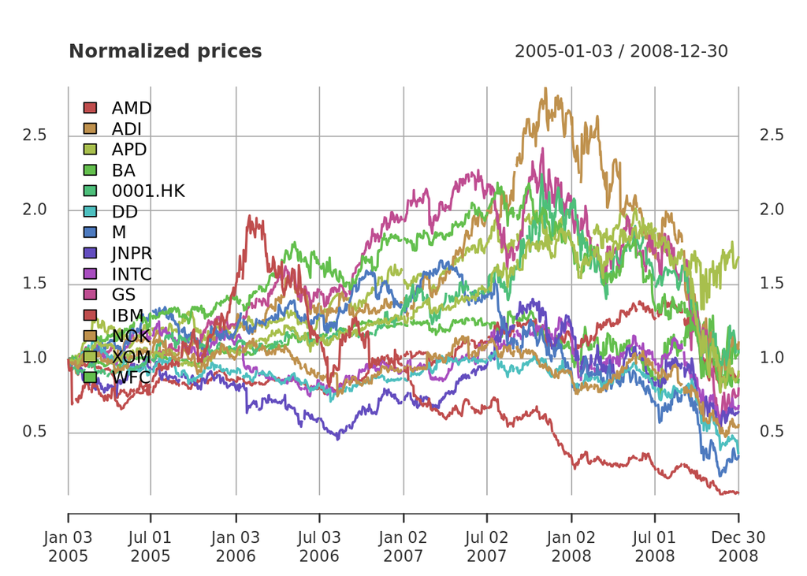

```r
plot(prices/rep(prices[1, ], each = nrow(prices)), col = rainbow10equal, legend.loc = "topleft",
     main = "Normalized prices")
```

Divide data into a training set and a test set

```r
T_trn <- round(0.7*T)  # 70% of data
X_log_trn <- X_log[1:T_trn, ]
X_log_tst <- X_log[(T_trn+1):T, ]
X_lin_trn <- X_lin[1:T_trn, ]
X_lin_tst <- X_lin[(T_trn+1):T, ]
```

```r
#mu <- colMeans(X_log_trn)
mu <- colMeans(X_log_trn, na.rm = TRUE)
#Sigma <- cov(X_log_trn)
Sigma <- cov(X_log_trn)
mu
```

```
##           AMD           ADI           APD            BA       0001.HK
## -5.731565e-04 -2.022960e-05  8.489256e-04  1.004808e-03  8.269906e-04
##            DD             M          JNPR          INTC            GS
##  7.889687e-05  3.125730e-04  3.876119e-04  3.272465e-04  1.125398e-03
##           IBM           NOK           XOM           WFC
##  2.469852e-04  1.411737e-03  1.052181e-03  2.603889e-04
```

```r
Sigma
```

```
##         AMD ADI APD BA 0001.HK DD  M JNPR INTC GS IBM NOK XOM WFC
## AMD      NA  NA  NA NA      NA NA NA   NA   NA NA  NA  NA  NA  NA
## ADI      NA  NA  NA NA      NA NA NA   NA   NA NA  NA  NA  NA  NA
## APD      NA  NA  NA NA      NA NA NA   NA   NA NA  NA  NA  NA  NA
## BA       NA  NA  NA NA      NA NA NA   NA   NA NA  NA  NA  NA  NA
## 0001.HK  NA  NA  NA NA      NA NA NA   NA   NA NA  NA  NA  NA  NA
## DD       NA  NA  NA NA      NA NA NA   NA   NA NA  NA  NA  NA  NA
## M        NA  NA  NA NA      NA NA NA   NA   NA NA  NA  NA  NA  NA
## JNPR     NA  NA  NA NA      NA NA NA   NA   NA NA  NA  NA  NA  NA
## INTC     NA  NA  NA NA      NA NA NA   NA   NA NA  NA  NA  NA  NA
## GS       NA  NA  NA NA      NA NA NA   NA   NA NA  NA  NA  NA  NA
## IBM      NA  NA  NA NA      NA NA NA   NA   NA NA  NA  NA  NA  NA
## NOK      NA  NA  NA NA      NA NA NA   NA   NA NA  NA  NA  NA  NA
## XOM      NA  NA  NA NA      NA NA NA   NA   NA NA  NA  NA  NA  NA
## WFC      NA  NA  NA NA      NA NA NA   NA   NA NA  NA  NA  NA  NA
```

Buy & Hold Strategy

```r
# a B&H portfolio is trivially the zero vector with a one on the stock held
w_BnH <- diag(N)
rownames(w_BnH) <- colnames(X_lin)
colnames(w_BnH) <- paste0("B&H-", colnames(X_lin))
dim(w_BnH)
```

```
## [1] 14 14
```

```r
dim(X_lin)
```

```
## [1] 1029   14
```

```r
w_BnH
```

```
##         B&H-AMD B&H-ADI B&H-APD B&H-BA B&H-0001.HK B&H-DD B&H-M B&H-JNPR
## AMD           1       0       0      0           0      0     0        0
## ADI           0       1       0      0           0      0     0        0
## APD           0       0       1      0           0      0     0        0
## BA            0       0       0      1           0      0     0        0
## 0001.HK       0       0       0      0           1      0     0        0
## DD            0       0       0      0           0      1     0        0
## M             0       0       0      0           0      0     1        0
## JNPR          0       0       0      0           0      0     0        1
## INTC          0       0       0      0           0      0     0        0
## GS            0       0       0      0           0      0     0        0
## IBM           0       0       0      0           0      0     0        0
## NOK           0       0       0      0           0      0     0        0
## XOM           0       0       0      0           0      0     0        0
## WFC           0       0       0      0           0      0     0        0
##         B&H-INTC B&H-GS B&H-IBM B&H-NOK B&H-XOM B&H-WFC
## AMD            0      0       0       0       0       0
## ADI            0      0       0       0       0       0
## APD            0      0       0       0       0       0
## BA             0      0       0       0       0       0
## 0001.HK        0      0       0       0       0       0
## DD             0      0       0       0       0       0
## M              0      0       0       0       0       0
## JNPR           0      0       0       0       0       0
## INTC           1      0       0       0       0       0
## GS             0      1       0       0       0       0
## IBM            0      0       1       0       0       0
## NOK            0      0       0       1       0       0
## XOM            0      0       0       0       1       0
## WFC            0      0       0       0       0       1
```

```r
# compute returns of all B&H portfolios
ret_BnH <- xts(X_lin %*% w_BnH, index(X_lin))
ret_BnH_trn <- ret_BnH[1:T_trn, ]
ret_BnH_tst <- ret_BnH[-c(1:T_trn), ]
head(ret_BnH)
```

```
##                 B&H-AMD      B&H-ADI       B&H-APD       B&H-BA  B&H-0001.HK
## 2005-01-04 -0.056048622 -0.027205057 -0.0191215985 -0.019423301 -0.006451873
## 2005-01-05 -0.022760961  0.004520013  0.0008783048  0.016606658 -0.035714103
## 2005-01-06 -0.001519038 -0.001687655  0.0061411156 -0.006495010 -0.003367121
## 2005-01-07  0.010142039  0.001408449  0.0054064185 -0.003367658 -0.020269776
## 2005-01-10  0.010542118 -0.003938120  0.0006940180  0.013317862  0.000000000
## 2005-01-11 -0.261798274 -0.009319409 -0.0180275860 -0.003138919 -0.010345111
##                  B&H-DD         B&H-M     B&H-JNPR     B&H-INTC       B&H-GS
## 2005-01-04 -0.021633782  0.0000000000 -0.038031058 -0.019939360 -0.006478880
## 2005-01-05 -0.010126133 -0.0055614820 -0.006201655 -0.009730145 -0.004507424
## 2005-01-06  0.011482312 -0.0003493698 -0.017940812  0.003126334  0.013776065
## 2005-01-07 -0.009494504 -0.0111884677  0.011119884  0.015138155 -0.004276084
## 2005-01-10  0.014794834  0.0185638671  0.014925486  0.003508416  0.001908739
## 2005-01-11 -0.020533855 -0.0001731711 -0.006579118 -0.014860135 -0.007715757
##                 B&H-IBM      B&H-NOK      B&H-XOM       B&H-WFC
## 2005-01-04 -0.010741365 -0.004490148 -0.006787762  0.0008081584
## 2005-01-05 -0.002068168  0.000000000 -0.005226319  0.0011292718
## 2005-01-06 -0.003109241  0.003221618  0.012729925  0.0035467536
## 2005-01-07 -0.004365046 -0.020552280 -0.006584109 -0.0012852730
## 2005-01-10 -0.001044821  0.015737598  0.003816192 -0.0006431041
## 2005-01-11 -0.007106617 -0.020012899 -0.002601017 -0.0019316841
```

```r
tail(ret_BnH, n = 10)
```

```
##                B&H-AMD      B&H-ADI      B&H-APD        B&H-BA  B&H-0001.HK
## 2008-12-16  0.01809955  0.058823290  0.038731167  0.0815693920  0.003750021
## 2008-12-17  0.01777778 -0.015014603 -0.020825092 -0.0210023243  0.002490713
## 2008-12-18 -0.02620087 -0.073170951 -0.038484890  0.0012185608 -0.013664444
## 2008-12-19  0.01793722  0.040021849 -0.017695649  0.0041395186  0.025818271
## 2008-12-22 -0.11013216 -0.032682925 -0.011151458 -0.0029098437 -0.054020778
## 2008-12-23 -0.02970297 -0.017438944 -0.013228813 -0.0235893955 -0.075924760
## 2008-12-24  0.01530612  0.008874457  0.007911859 -0.0007475173  0.025280840
## 2008-12-26          NA           NA           NA            NA           NA
## 2008-12-29          NA           NA           NA            NA           NA
## 2008-12-30  0.05238095  0.040309280  0.035586259  0.0315079017 -0.020689607
##                  B&H-DD       B&H-M    B&H-JNPR     B&H-INTC       B&H-GS
## 2008-12-16  0.051567653  0.03926403  0.04952849  0.071967045  0.143544427
## 2008-12-17 -0.009615554  0.18181832 -0.02696623 -0.024296608  0.036579594
## 2008-12-18 -0.027184007  0.04095897 -0.01327948 -0.065530970  0.016120548
## 2008-12-19  0.001995430  0.01919382 -0.01345786  0.012622897  0.008494974
## 2008-12-22 -0.021414192 -0.11958594 -0.01304891 -0.006924834 -0.046203427
## 2008-12-23 -0.017811787 -0.06844928  0.01081747 -0.018828754 -0.023376620
## 2008-12-24 -0.009844444  0.01262924  0.01248504  0.011371696  0.016489422
## 2008-12-26           NA          NA          NA           NA           NA
## 2008-12-29           NA          NA          NA           NA           NA
## 2008-12-30  0.015013314  0.05849252  0.01576192  0.039632194  0.071838996
##                 B&H-IBM      B&H-NOK      B&H-XOM      B&H-WFC
## 2008-12-16  0.043856458  0.065316840  0.039899679  0.142308876
## 2008-12-17 -0.006481256  0.012262618 -0.025017876  0.006715943
## 2008-12-18 -0.021434895 -0.039975957 -0.050086349 -0.011007141
## 2008-12-19 -0.005714826 -0.010094665 -0.025714381 -0.009780316
## 2008-12-22 -0.018318894 -0.024219277 -0.001466015 -0.066076719
## 2008-12-23 -0.016953193 -0.008491071  0.002535923 -0.015681779
## 2008-12-24 -0.000992490 -0.009222802  0.009054921  0.018154597
## 2008-12-26           NA           NA           NA           NA
## 2008-12-29           NA           NA           NA           NA
## 2008-12-30  0.028308463  0.052034851  0.007305166  0.034854513
```

```r
# performance measures
t(table.AnnualizedReturns(ret_BnH_trn))
```

```
##             Annualized Return Annualized Std Dev Annualized Sharpe (Rf=0%)
## B&H-AMD               -0.1481             0.4544                   -0.3260
## B&H-ADI               -0.0119             0.2799                   -0.0426
## B&H-APD                0.1685             0.2003                    0.8411
## B&H-BA                 0.2089             0.2174                    0.9608
## B&H-0001.HK            0.2210             0.2436                    0.9072
## B&H-DD                -0.0234             0.2162                   -0.1081
## B&H-M                  0.0094             0.2885                    0.0325
## B&H-JNPR               0.0455             0.3814                    0.1192
## B&H-INTC               0.0164             0.2440                    0.0672
## B&H-GS                 0.2259             0.2454                    0.9207
## B&H-IBM                0.0270             0.1680                    0.1605
## B&H-NOK                0.3489             0.2672                    1.3056
## B&H-XOM                0.2787             0.2165                    1.2874
## B&H-WFC                0.0428             0.1622                    0.2635
```

```r
t(table.AnnualizedReturns(ret_BnH_tst))
```

```
##             Annualized Return Annualized Std Dev Annualized Sharpe (Rf=0%)
## B&H-AMD               -0.7676             0.7966                   -0.9636
## B&H-ADI               -0.3478             0.4646                   -0.7485
## B&H-APD               -0.4455             0.5106                   -0.8725
## B&H-BA                -0.4856             0.4633                   -1.0482
## B&H-0001.HK           -0.3201             0.5619                   -0.5696
## B&H-DD                -0.4869             0.4753                   -1.0244
## B&H-M                 -0.6439             0.7998                   -0.8051
## B&H-JNPR              -0.3899             0.6161                   -0.6329
## B&H-INTC              -0.3482             0.5165                   -0.6741
## B&H-GS                -0.5524             0.7761                   -0.7118
## B&H-IBM               -0.0895             0.3492                   -0.2562
## B&H-NOK               -0.4979             0.5803                   -0.8579
## B&H-XOM               -0.0698             0.5030                   -0.1388
## B&H-WFC               -0.1035             0.7950                   -0.1302
```

```r
table.DownsideRisk(ret_BnH_trn)
```

```
##                               B&H-AMD B&H-ADI B&H-APD  B&H-BA B&H-0001.HK
## Semi Deviation                 0.0214  0.0127  0.0088  0.0093      0.0108
## Gain Deviation                 0.0184  0.0122  0.0087  0.0096      0.0108
## Loss Deviation                 0.0230  0.0131  0.0081  0.0079      0.0105
## Downside Deviation (MAR=210%)  0.0258  0.0174  0.0136  0.0141      0.0152
## Downside Deviation (Rf=0%)     0.0214  0.0126  0.0084  0.0089      0.0103
## Downside Deviation (0%)        0.0214  0.0126  0.0084  0.0089      0.0103
## Maximum Drawdown               0.7131  0.3095  0.1822  0.1686      0.1700
## Historical VaR (95%)          -0.0409 -0.0239 -0.0194 -0.0200     -0.0230
## Historical ES (95%)           -0.0650 -0.0368 -0.0271 -0.0270     -0.0346
## Modified VaR (95%)            -0.0493 -0.0279 -0.0195 -0.0195     -0.0232
## Modified ES (95%)             -0.1340 -0.0646 -0.0266 -0.0249     -0.0334
##                                B&H-DD   B&H-M B&H-JNPR B&H-INTC  B&H-GS B&H-IBM
## Semi Deviation                 0.0098  0.0122   0.0175   0.0113  0.0109  0.0077
## Gain Deviation                 0.0083  0.0135   0.0157   0.0093  0.0104  0.0068
## Loss Deviation                 0.0093  0.0112   0.0177   0.0111  0.0103  0.0079
## Downside Deviation (MAR=210%)  0.0150  0.0172   0.0218   0.0161  0.0154  0.0128
## Downside Deviation (Rf=0%)     0.0098  0.0121   0.0172   0.0112  0.0105  0.0077
## Downside Deviation (0%)        0.0098  0.0121   0.0172   0.0112  0.0105  0.0077
## Maximum Drawdown               0.3520  0.3692   0.5752   0.3887  0.3042  0.2500
## Historical VaR (95%)          -0.0201 -0.0287  -0.0336  -0.0211 -0.0231 -0.0154
## Historical ES (95%)           -0.0290 -0.0380  -0.0525  -0.0342 -0.0336 -0.0245
## Modified VaR (95%)            -0.0230 -0.0262  -0.0391  -0.0263 -0.0240 -0.0179
## Modified ES (95%)             -0.0423 -0.0324  -0.0896  -0.0529 -0.0363 -0.0379
##                               B&H-NOK B&H-XOM B&H-WFC
## Semi Deviation                 0.0116  0.0100  0.0068
## Gain Deviation                 0.0123  0.0080  0.0080
## Loss Deviation                 0.0112  0.0093  0.0066
## Downside Deviation (MAR=210%)  0.0157  0.0144  0.0121
## Downside Deviation (Rf=0%)     0.0110  0.0095  0.0067
## Downside Deviation (0%)        0.0110  0.0095  0.0067
## Maximum Drawdown               0.2029  0.1893  0.1314
## Historical VaR (95%)          -0.0231 -0.0211 -0.0136
## Historical ES (95%)           -0.0345 -0.0305 -0.0217
## Modified VaR (95%)            -0.0244 -0.0224 -0.0135
## Modified ES (95%)             -0.0386 -0.0314 -0.0135
```

To compute the wealth or cumulative P&L, we have two options: one assumes the same quantity is repeateadly invested, whereas the other assumes reinvesting (compounding):

```r
# compute cumulative wealth
dim(ret_BnH_trn)
```

```
## [1] 720  14
```

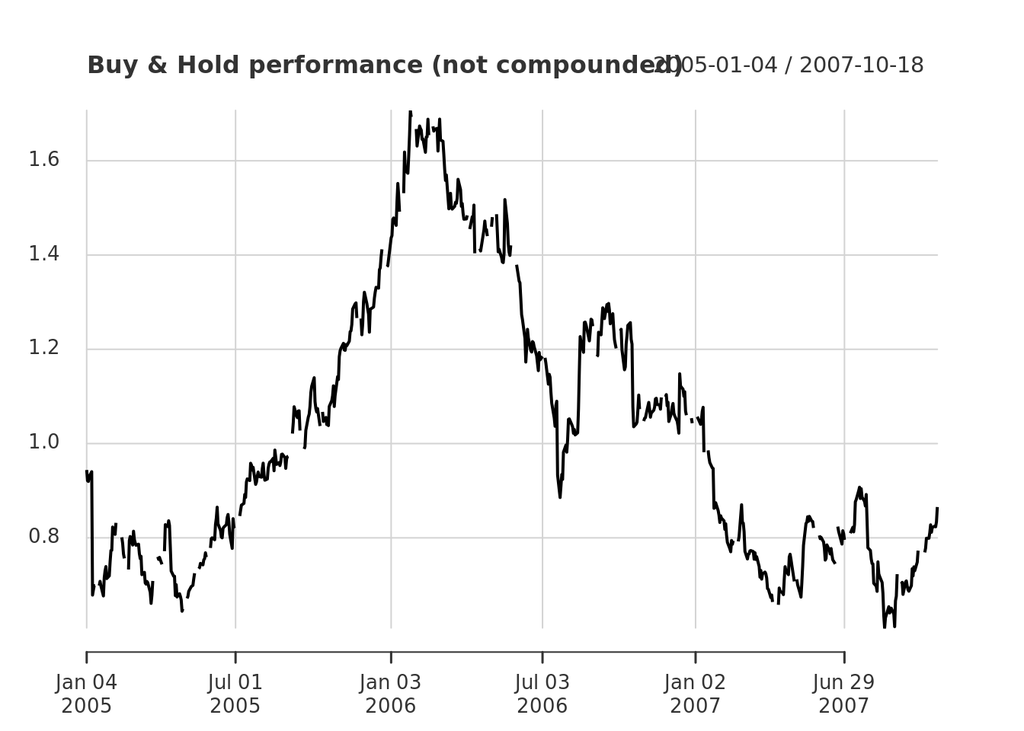

```r
wealth_arith_BnH_trn <- 1 + cumsum(ret_BnH_trn)  # initial budget of 1$
wealth_geom_BnH_trn <- cumprod(1 + ret_BnH_trn)  # initial budget of 1$

# plots
# same as:
#   plot(wealth_arith_BnH_trn[, 1], main = "Buy & Hold performance (not compounded)", ylab = "wealth")
chart.CumReturns(ret_BnH_trn[, 1], main = "Buy & Hold performance (not compounded)",
                 geometric = FALSE, wealth.index = TRUE)
```

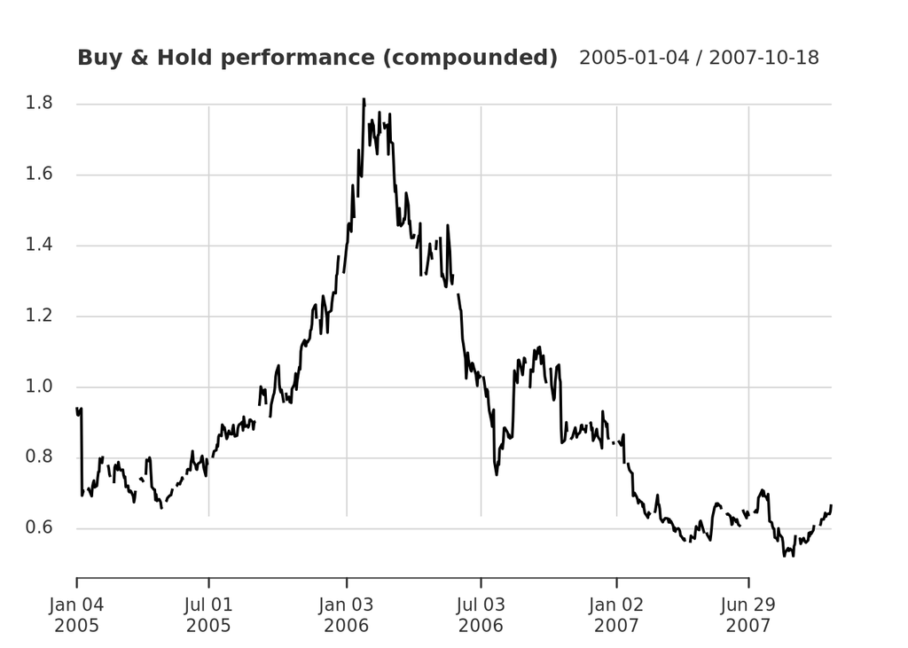

```r
# same as:
#   plot(wealth_geom_BnH_trn[, 1], main = "Buy & Hold performance (compounded)", ylab = "wealth")
chart.CumReturns(ret_BnH_trn[, 1], main = "Buy & Hold performance (compounded)",
                 geometric = TRUE, wealth.index = TRUE)
```

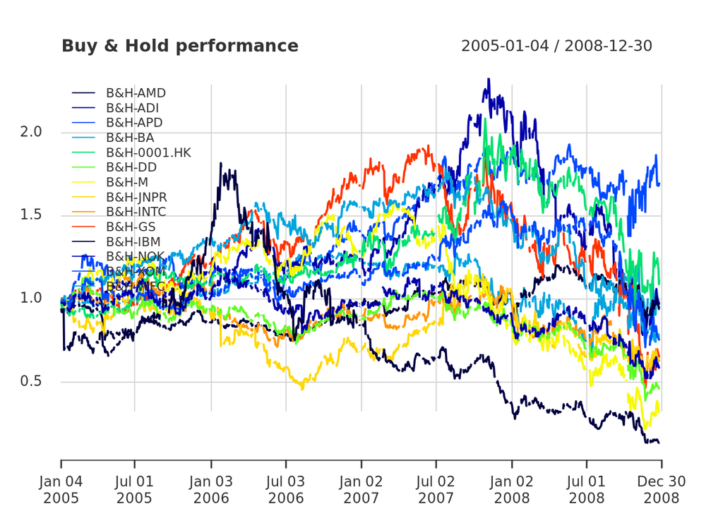

```r
# more plots
chart.CumReturns(ret_BnH, main = "Buy & Hold performance",
                 wealth.index = TRUE, legend.loc = "topleft", colorset = rich10equal)
```

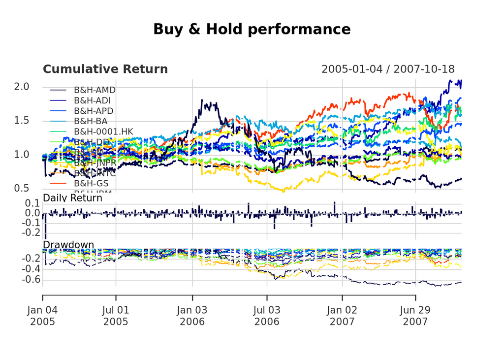

```r
charts.PerformanceSummary(ret_BnH_trn, main = "Buy & Hold performance",
                          wealth.index = TRUE, colorset = rich10equal)
```

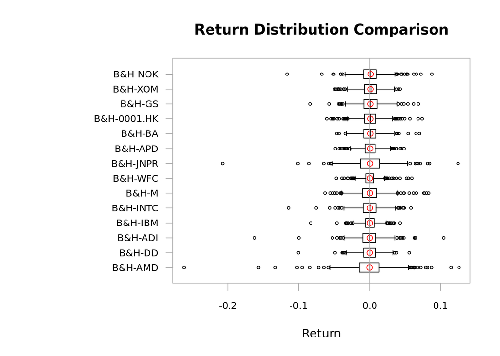

```r
chart.Boxplot(ret_BnH_trn)
```

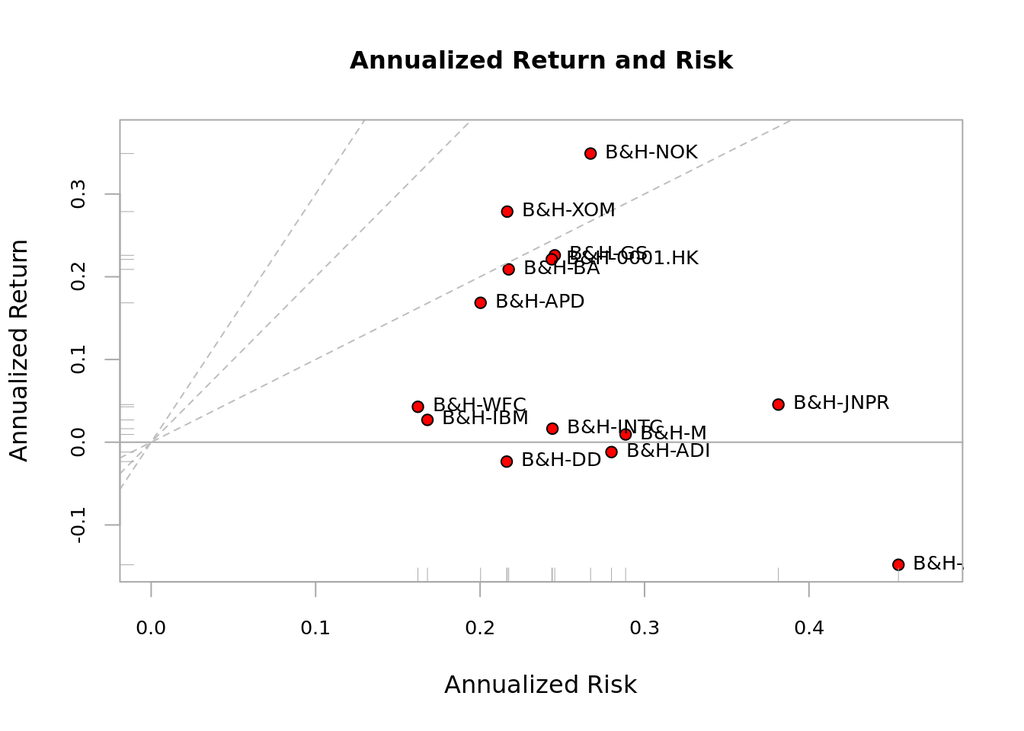

```r
chart.RiskReturnScatter(ret_BnH_trn, symbolset = 21, bg = "red")
```

# Comparison of $\frac{1}{N}$ portfolio, quintile portfolio, and GMRP

The EWP or $\frac{1}{N}$ portfolio allocates equal dollar weight to each stock: **w**$=\frac{1}{N}$**1**.

```r
w_EWP <- rep(1/N, N)
names(w_EWP) <- colnames(X_lin)
w_EWP
```

```
##        AMD        ADI        APD         BA    0001.HK         DD          M
## 0.07142857 0.07142857 0.07142857 0.07142857 0.07142857 0.07142857 0.07142857
##       JNPR       INTC         GS        IBM        NOK        XOM        WFC
## 0.07142857 0.07142857 0.07142857 0.07142857 0.07142857 0.07142857 0.07142857
```

**Quintile portfolios** are widely used by practitioners. The idea is to 1) rank the N stocks, 2) divide them into five parts, and 3) long the top part (and possibly short the bottom part). One can rank the stocks in a multitude of ways (typically based on expensive factors that investment funds buy at a premium price). For our experiments, we will consider three possible rankings according to:

1. $\mu$
2. $\frac{\mu}{diag(\Sigma)}$
3. $\frac{\mu}{diag(\sqrt{\Sigma})}$

```r
# find indices of sorted stocks
i1 <- sort(mu, decreasing = TRUE, index.return = TRUE)$ix
i2 <- sort(mu/diag(Sigma), decreasing = TRUE, index.return = TRUE)$ix
i3 <- sort(mu/sqrt(diag(Sigma)), decreasing = TRUE, index.return = TRUE)$ix
mu
```

```
##           AMD           ADI           APD            BA       0001.HK
## -5.731565e-04 -2.022960e-05  8.489256e-04  1.004808e-03  8.269906e-04
##            DD             M          JNPR          INTC            GS
##  7.889687e-05  3.125730e-04  3.876119e-04  3.272465e-04  1.125398e-03
##           IBM           NOK           XOM           WFC
##  2.469852e-04  1.411737e-03  1.052181e-03  2.603889e-04
```

```r
i1
```

```
##  [1] 12 10 13  4  3  5  8  9  7 14 11  6  2  1
```

```r
# create portfolios
w_QuintP_1 <- w_QuintP_2 <- w_QuintP_3 <- rep(0, N)
w_QuintP_1[i1[1:round(N/5)]] <- 1/round(N/5)
w_QuintP_2[i2[1:round(N/5)]] <- 1/round(N/5)
w_QuintP_3[i3[1:round(N/5)]] <- 1/round(N/5)
w_QuintP <- cbind("QuintP (mu)"        = w_QuintP_1,
                  "QuintP (mu/sigma2)" = w_QuintP_2,
                  "QuintP (mu/sigma)"  = w_QuintP_3)
rownames(w_QuintP) <- colnames(X_lin)
w_QuintP
```

```
##         QuintP (mu) QuintP (mu/sigma2) QuintP (mu/sigma)
## AMD       0.0000000                  0                 0
## ADI       0.0000000                  0                 0
## APD       0.0000000                  0                 0
## BA        0.0000000                  0                 0
## 0001.HK   0.0000000                  0                 0
## DD        0.0000000                  0                 0
## M         0.0000000                  0                 0
## JNPR      0.0000000                  0                 0
## INTC      0.0000000                  0                 0
## GS        0.3333333                  0                 0
## IBM       0.0000000                  0                 0
## NOK       0.3333333                  0                 0
## XOM       0.3333333                  0                 0
## WFC       0.0000000                  0                 0
```

The **global maximum return portfolio (GMRP)** chooses the stock with the hightest return during the in-sample period:

```r
i_max <- which.max(mu)
w_GMRP <- rep(0, N)
w_GMRP[i_max] <- 1
names(w_GMRP) <- colnames(X_lin)
w_GMRP
```

```
##     AMD     ADI     APD      BA 0001.HK      DD       M    JNPR    INTC      GS
##       0       0       0       0       0       0       0       0       0       0
##     IBM     NOK     XOM     WFC
##       0       1       0       0
```

We can now compare the allocations of the portfolios:

```r
# put together all portfolios
w_heuristic <- cbind("EWP" = w_EWP, w_QuintP, "GMRP" = w_GMRP)
round(w_heuristic, digits = 2)
```

```
##          EWP QuintP (mu) QuintP (mu/sigma2) QuintP (mu/sigma) GMRP
## AMD     0.07        0.00                  0                 0    0
## ADI     0.07        0.00                  0                 0    0
## APD     0.07        0.00                  0                 0    0
## BA      0.07        0.00                  0                 0    0
## 0001.HK 0.07        0.00                  0                 0    0
## DD      0.07        0.00                  0                 0    0
## M       0.07        0.00                  0                 0    0
## JNPR    0.07        0.00                  0                 0    0
## INTC    0.07        0.00                  0                 0    0
## GS      0.07        0.33                  0                 0    0
## IBM     0.07        0.00                  0                 0    0
## NOK     0.07        0.33                  0                 0    1
## XOM     0.07        0.33                  0                 0    0
## WFC     0.07        0.00                  0                 0    0
```

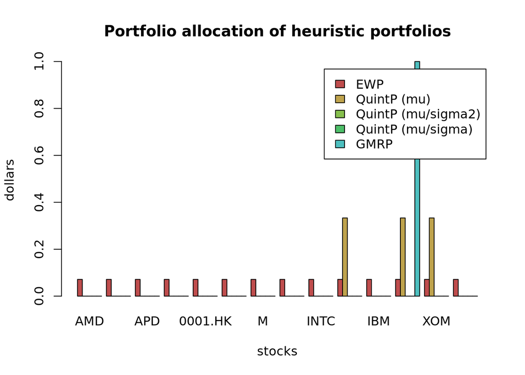

```r
barplot(t(w_heuristic), col = rainbow8equal[1:5],
        legend = colnames(w_heuristic), beside = TRUE,
        main = "Portfolio allocation of heuristic portfolios",
        xlab = "stocks", ylab = "dollars")
```

Then we can compare the performance (in-sample vs out-of-sample):

```r
# compute returns of all portfolios
ret_heuristic <- xts(X_lin %*% w_heuristic, index(X_lin))
ret_heuristic$`QuintP (mu/sigma2)` <- NULL  # remove since it coincides with "QuintP (mu/sigma)"
ret_heuristic_trn <- ret_heuristic[1:T_trn, ]
ret_heuristic_tst <- ret_heuristic[-c(1:T_trn), ]

# performance
t(table.AnnualizedReturns(ret_heuristic_trn))
```

```
##                   Annualized Return Annualized Std Dev
## EWP                          0.1200             0.1489
## QuintP (mu)                  0.2992             0.1874
## QuintP (mu/sigma)            0.0000             0.0000
## GMRP                         0.3489             0.2672
##                   Annualized Sharpe (Rf=0%)
## EWP                                  0.8058
## QuintP (mu)                          1.5967
## QuintP (mu/sigma)                       NaN
## GMRP                                 1.3056
```

```r
t(table.AnnualizedReturns(ret_heuristic_tst))
```

```
##                   Annualized Return Annualized Std Dev
## EWP                         -0.3800             0.4324
## QuintP (mu)                 -0.3683             0.5185
## QuintP (mu/sigma)            0.0000             0.0000
## GMRP                        -0.4979             0.5803
##                   Annualized Sharpe (Rf=0%)
## EWP                                 -0.8790
## QuintP (mu)                         -0.7103
## QuintP (mu/sigma)                       NaN
## GMRP                                -0.8579
```

Let’s plot the wealth evolution (cumulative PnL) over time:

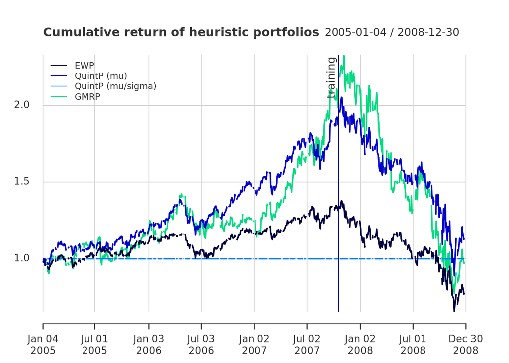

```r
{ chart.CumReturns(ret_heuristic, main = "Cumulative return of heuristic portfolios",
                   wealth.index = TRUE, legend.loc = "topleft", colorset = rich8equal)
  addEventLines(xts("training", index(X_lin[T_trn])), srt=90, pos=2, lwd = 2, col = "darkblue") }
```

Finally, we can plot the risk-return scatter plot:

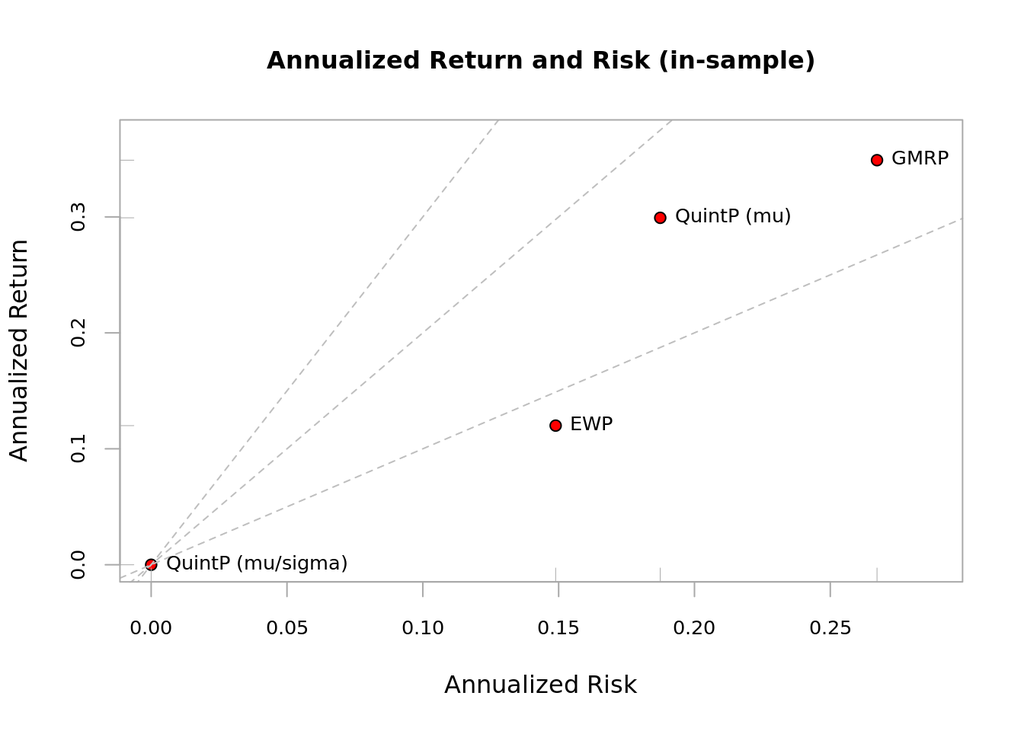

```r
chart.RiskReturnScatter(ret_heuristic_trn, symbolset = 21, bg = "red",
                        main = "Annualized Return and Risk (in-sample)")
```